# Efecto de los microplásticos sobre la selección de concha en Pagurus bernhardus

Autor/a

Carlos Fuentes

## Introducción

Los microplásticos, definidos como partículas de plástico menores de 5 mm, se han convertido en uno de los contaminantes más extendidos y de mayor problemática en los ecosistemas marinos (Andrady 2011; Cole et al. 2011; Yang, Chen, y Wang 2021). Su presencia ha sido documentada en prácticamente todos los ambientes oceánicos, desde zonas costeras hasta mar abierto y aguas profundas, lo que los ha convertido en una preocupación ambiental de alcance global (Yang, Chen, y Wang 2021). Debido a su pequeño tamaño, los microplásticos pueden ser ingeridos por una amplia variedad de especies marinas, incluyendo peces, moluscos, crustáceos y equinodermos, con potenciales efectos sobre su fisiología y comportamiento (Fotheringham 1976; Yang, Chen, y Wang 2021)

El cangrejo ermitaño común europeo, *Pagurus bernhardus*, constituye un modelo adecuado para estudiar estos efectos debido a que su supervivencia depende en gran medida de la selección de conchas (Hazlett 1981; Fotheringham 1976). Estos organismos habitan conchas vacías de gasterópodos para proteger su abdomen blando de los depredadores, y la calidad de la concha influye sobre su crecimiento, fecundidad y supervivencia (Williams y McDermott 2004). La elección de una nueva concha requiere reunir información sobre las alternativas disponibles, evaluar su calidad y decidir si realizar o no el cambio, lo que convierte este comportamiento en un proceso asociado a la cognición (Crump et al. 2020b; Rodrigues, Dunham, y Coates 2000).

En este trabajo se analizan los datos experimentales de Crump et al. (2020a), obtenidos a partir de individuos expuestos y no expuestos a microplásticos. El objetivo es evaluar si la exposición a microplásticos reduce la probabilidad de que un cangrejo ermitaño ocupe una concha óptima, considerando además el efecto del peso corporal. En base a lo anterior, se plantea como hipótesis que los individuos expuestos presentarán una menor probabilidad de entrar en la concha óptima que aquellos pertenecientes al grupo control.

## Métodos

### Origen de los datos

Los datos utilizados en este estudio provienen del repositorio Dryad (Crump et al. 2020a) y fueron descargados el 23/09/2026. Estos corresponden al experimento desarrollado por Crump et al. (2020b) para evaluar los efectos de la exposición a microplásticos sobre la selección de conchas en el cangrejo ermitaño común europeo (*Pagurus bernhardus*). El estudio incluyó 64 hembras recolectadas en Ballywalter Beach, Irlanda del Norte, las cuales fueron asignadas aleatoriamente a un tratamiento control o a un tratamiento con esferas de polietileno de 4 mm (25 partículas por litro). Los individuos permanecieron durante cinco días bajo estas condiciones y posteriormente fueron transferidos a una concha subóptima equivalente al 50 % de su preferencia de peso. Tras dos horas de aclimatación, se les ofreció una concha óptima y se registró durante 30 minutos si establecían contacto con ella, el tiempo requerido para hacerlo, el tiempo que la investigaban y si finalmente ingresaban en la nueva concha. Para este trabajo se utilizaron todas las observaciones disponibles en el archivo original, sin aplicar filtros ni excluir registros.

**Código**

```r
library(readxl)

datos <- read_excel("microplastics_impair_crustacean_cognition.xlsx", na = "na")
```

### Variables

**Código**

```r
data.frame(
  Variable = c("Tratamiento",
               "Peso corporal",
               "Contacto con la concha óptima",
               "Entrada a la concha óptima",
               "Tiempo hasta contactar la concha",
               "Tiempo hasta entrar en la concha",
               "Tiempo de investigación de la concha"),
  Tipo = c("Categórica",
           "Numérica",
           "Categórica dicotómica",
           "Categórica dicotómica",
           "Numérica",
           "Numérica",
           "Numérica"),
  `Unidad o categorías` = c("Control, Plástico",
                            "Gramos",
                            "0 = No contactó, 1 = Sí contactó",
                            "0 = No entró, 1 = Sí entró",
                            "Segundos",
                            "Segundos",
                            "Segundos"),
  check.names = FALSE
) |>
  knitr::kable(align = "lll")
```

Tabla 1: Variables utilizadas en el análisis.

| Variable | Tipo | Unidad o categorías |
| --- | --- | --- |
| Tratamiento | Categórica | Control, Plástico |
| Peso corporal | Numérica | Gramos |
| Contacto con la concha óptima | Categórica dicotómica | 0 = No contactó, 1 = Sí contactó |
| Entrada a la concha óptima | Categórica dicotómica | 0 = No entró, 1 = Sí entró |
| Tiempo hasta contactar la concha | Numérica | Segundos |
| Tiempo hasta entrar en la concha | Numérica | Segundos |
| Tiempo de investigación de la concha | Numérica | Segundos |

### Proceso de limpieza

La Tabla 1 resume las variables utilizadas en el análisis. Los datos se importaron desde el archivo original mediante la función `read_excel()`, declarando `na` como valor faltante, y se conservaron siete de las nueve columnas, porque las dos restantes (peso de las conchas ofrecidas) se calculan a partir del peso corporal (En este caso no es un dato de interes para responder la hipotesis). Los tratamientos se colocarón como “Control” y “Plástico”. Posteriormente, se verificó la presencia de datos faltantes y la relación entre las variables conductuales. En total fueron 64 individuos (35 ejemplares como grupo control y 29 ejemplares que fueron expuestos a plástico) y se comprobó que ningún individuo ingresó a la concha óptima sin haberla contactado previamente (Tabla 2). Los tiempos de entrada a la concha tienen un limite de 1800 s (30 minutos), valor asignado a los individuos que no realizaron la conducta. Los 30 valores faltantes del tiempo de investigación corresponden a 29 individuos que no contactaron la concha y a un control que sí la contactó pero no tiene tiempo registrado.

**Código**

```r
si_no <- c("No", "Sí")
table(Contactó = factor(datos$contacted_shell, levels = c(0, 1), labels = si_no),
      Entró = factor(datos$entered_shell, levels = c(0, 1), labels = si_no)) |>
  as.data.frame(responseName = "Individuos") |>
  knitr::kable()
```

Tabla 2: Relación entre el contacto y la entrada en la concha óptima.

| Contactó | Entró | Individuos |
| --- | --- | --- |
| No | No | 29 |
| Sí | No | 5 |
| No | Sí | 0 |
| Sí | Sí | 30 |

**Código**

```r
library(tidyverse)
library(readxl)

datos <- datos |>
  rename(any_of(c(peso = "weight_g", contacto = "contacted_shell", entro = "entered_shell",
                  lat_contacto = "contact_latency_s", lat_investigacion = "investigation_latency_s",
                  lat_entrada = "entrance_latency_s"))) |>
  select(tx, peso, contacto, entro, lat_contacto, lat_investigacion, lat_entrada) |>
  mutate(tratamiento = factor(if_else(tx %in% c("ctrl", "Control"), "Control", "Plástico"),
                              levels = c("Control", "Plástico")),
         entrada = factor(entro, levels = c(0, 1), labels = c("No entró", "Entró")))

prop <- datos |>
  pivot_longer(cols = c(contacto, entro), names_to = "conducta", values_to = "valor") |>
  mutate(conducta = if_else(conducta == "contacto", "Contactó la concha", "Entró en la concha")) |>
  group_by(tratamiento, conducta) |>
  summarise(n = n(), exito = sum(valor), proporcion = exito / n, .groups = "drop")

lat <- datos |>
  pivot_longer(cols = c(lat_contacto, lat_entrada), names_to = "evento", values_to = "segundos") |>
  mutate(evento = if_else(evento == "lat_contacto", "Hasta contactar", "Hasta entrar"))
```

### Análisis estadístico

Esta etapa es exploratoria, por lo que no se aplicaron pruebas de hipótesis y la hipótesis se abordó de forma descriptiva. Como la variable de interés (entrada en la concha) es dicotómica, se calcularon frecuencias y porcentajes por tratamiento, lo que permite comparar la probabilidad de entrar entre expuestos y control; lo mismo se hizo con el contacto. Las tiempos de entrada se resumieron con mediana y cuartiles (Q1–Q3) y se contó cuántos individuos llegaron al tope de 1800 s, porque ese límite hace que la media no sea representativa. El peso se resumió con media, desviación estándar, mediana y cuartiles para describir el tamaño de cada grupo. Las tablas se hicieron con `knitr::kable()` y las figuras con `ggplot2`.

## Resultados

**Código**

```r
datos <- datos |>
  rename(any_of(c(peso = "weight_g", contacto = "contacted_shell", entro = "entered_shell",
                  lat_contacto = "contact_latency_s", lat_investigacion = "investigation_latency_s",
                  lat_entrada = "entrance_latency_s"))) |>
  select(tx, peso, contacto, entro, lat_contacto, lat_investigacion, lat_entrada) |>
  mutate(lat_investigacion = as.numeric(lat_investigacion),   # asegura que sea numérica
         tratamiento = factor(if_else(tx %in% c("ctrl", "Control"), "Control", "Plástico"),
                              levels = c("Control", "Plástico")),
         entrada = factor(entro, levels = c(0, 1), labels = c("No entró", "Entró")))
prop <- datos |>
  pivot_longer(cols = c(contacto, entro), names_to = "conducta", values_to = "valor") |>
  mutate(conducta = if_else(conducta == "contacto", "Contactó la concha", "Entró en la concha"),
         conducta = factor(conducta, levels = c("Entró en la concha", "Contactó la concha"))) |>
  group_by(tratamiento, conducta) |>
  summarise(n = n(), exito = sum(valor), proporcion = exito / n, .groups = "drop")
lat <- datos |>
  pivot_longer(cols = c(lat_contacto, lat_entrada), names_to = "evento", values_to = "segundos") |>
  mutate(evento = if_else(evento == "lat_contacto", "Hasta contactar", "Hasta entrar"))
```

**Código**

```r
datos |>
  group_by(tratamiento) |>
  summarise(n = n(),
              Contactaron = sum(contacto),
            `% contactaron` = 100 * mean(contacto),
            Entraron = sum(entro),
            `% entraron` = 100 * mean(entro),
            `Peso medio (g)` = mean(peso),
            `Desviación estándar del peso` = sd(peso)) |>
  rename(Tratamiento = tratamiento) |>
  knitr::kable(digits = 2)
```

Tabla 3: Individuos que contactaron y que entraron en la concha óptima, y peso corporal

| Tratamiento | n | Contactaron | % contactaron | Entraron | % entraron | Peso medio (g) | Desviación estándar del peso |
| --- | --- | --- | --- | --- | --- | --- | --- |
| Control | 35 | 25 | 71.43 | 21 | 60.00 | 0.21 | 0.10 |
| Plástico | 29 | 10 | 34.48 | 9 | 31.03 | 0.18 | 0.08 |

En la Tabla 3 y la Figura 1 se compara entre tratamientos la proporción de individuos que entraron en la concha óptima. La figura tiene dos paneles, uno para la entrada en la concha (izquierda) y otro para el contacto con ella (derecha), con una barra por tratamiento. Entraron en la concha 21 de 35 individuos control (60%) y 9 de 29 individuos expuestos al plástico (31%). Contactaron la concha 25 de 35 controles (71.4 %) y 10 de 29 expuestos (34.5 %); cuatro individuos control y uno expuesto la contactaron sin entrar en ella.

**Código**

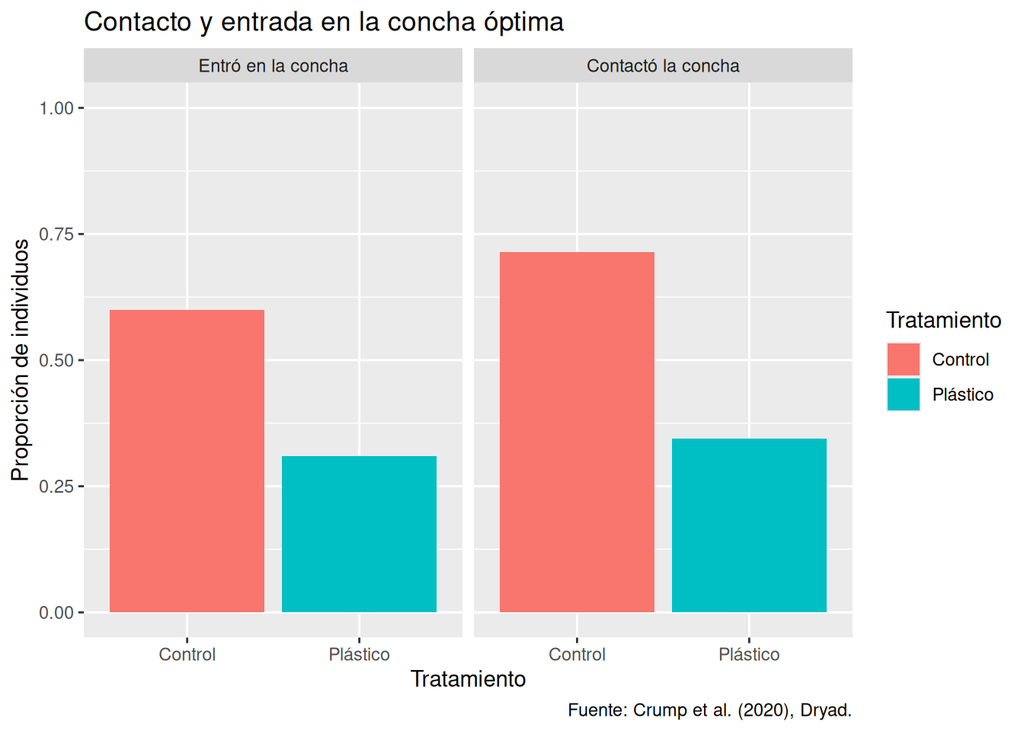

Figura 1: Porcentaje de individuos que contactaron y entraron en la concha óptima.

```r
ggplot(prop, aes(x = tratamiento, y = proporcion, fill = tratamiento)) +
  geom_col() +
  facet_wrap(~ conducta) +
  ylim(0, 1) +
  labs(x = "Tratamiento",
       y = "Proporción de individuos",
       fill = "Tratamiento",
       title = "Contacto y entrada en la concha óptima",
       caption = "Fuente: Crump et al. (2020), Dryad.")
```

Para describir el tamaño de los individuos de cada grupo, la Figura 2 muestra el peso corporal en un diagrama de cajas. El peso medio fue de 0.21 g en el grupo control (DE = 0.10) y de 0.18 g en el grupo con plástico (DE = 0.08) (Tabla 3). La mediana fue de 0.19 g en el control (Q1–Q3: 0.125–0.255; rango: 0.07–0.44 g) y de 0.15 g con plástico (0.13–0.23; rango: 0.07–0.37 g).

**Código**

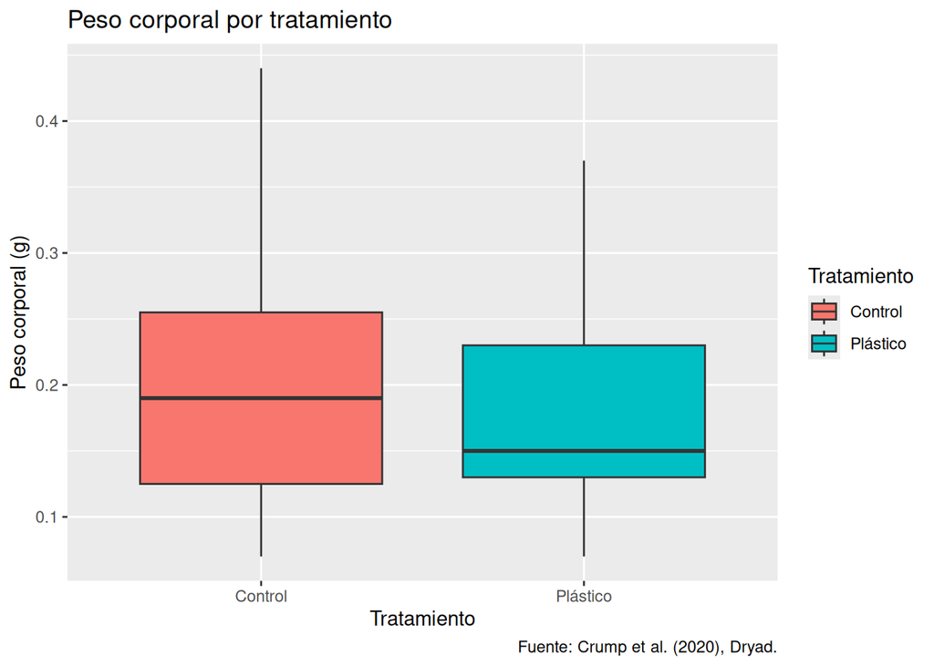

Figura 2: Peso corporal de Pagurus bernhardus según tratamiento.

```r
ggplot(datos, aes(x = tratamiento, y = peso, fill = tratamiento)) +
  geom_boxplot() +
  labs(x = "Tratamiento",
       y = "Peso corporal (g)",
       fill = "Tratamiento",
       title = "Peso corporal por tratamiento",
       caption = "Fuente: Crump et al. (2020), Dryad.")
```

**Código**

```r
lat |>
  group_by(tratamiento, evento) |>
  summarise(Mediana = median(segundos),
            Q1 = quantile(segundos, 0.25),
            Q3 = quantile(segundos, 0.75),
            `En el tope` = sum(segundos == 1800),
            .groups = "drop") |>
  rename(Tratamiento = tratamiento, Evento = evento) |>
  knitr::kable(digits = 0)
```

Tabla 4: Tiempo de contacto y hasta entrar en la concha óptima.

| Tratamiento | Evento | Mediana | Q1 | Q3 | En el tope |
| --- | --- | --- | --- | --- | --- |
| Control | Hasta contactar | 948 | 184 | 1800 | 10 |
| Control | Hasta entrar | 1379 | 511 | 1800 | 14 |
| Plástico | Hasta contactar | 1800 | 1356 | 1800 | 19 |
| Plástico | Hasta entrar | 1800 | 1559 | 1800 | 20 |

**Código**

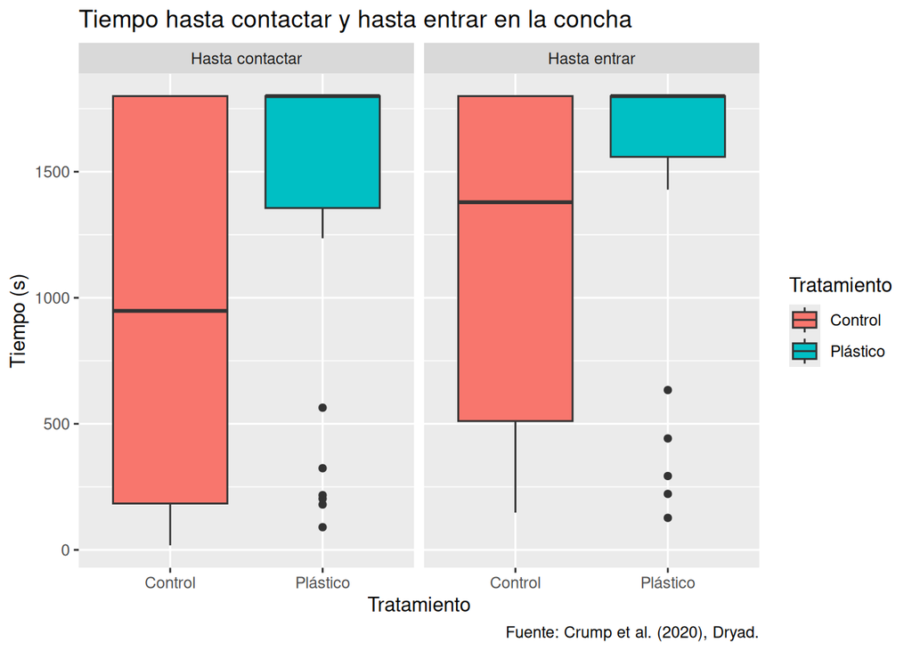

Figura 3: Tiempo hasta contactar y hasta entrar en la concha óptima

```r
ggplot(lat, aes(x = tratamiento, y = segundos, fill = tratamiento)) +
  geom_boxplot() +
  facet_wrap(~ evento) +
  labs(x = "Tratamiento",
       y = "Tiempo (s)",
       fill = "Tratamiento",
       title = "Tiempo hasta contactar y hasta entrar en la concha",
       caption = "Fuente: Crump et al. (2020), Dryad.")
```

## Referencias

Andrady, Anthony L. 2011. «Microplastics in the Marine Environment». *Marine Pollution Bulletin* 62 (8): 1596-1605. https://doi.org/10.1016/j.marpolbul.2011.05.030.

Cole, Matthew, Pennie Lindeque, Claudia Halsband, y Tamara S. Galloway. 2011. «Microplastics as Contaminants in the Marine Environment: A Review». *Marine Pollution Bulletin* 62 (12): 2588-97. https://doi.org/10.1016/j.marpolbul.2011.09.025.

Crump, Andrew, Charlotte Mullens, Emily J. Bethell, Eoghan M. Cunningham, y Gareth Arnott. 2020a. «Data from: Microplastics disrupt hermit crab shell selection». Dryad. https://doi.org/10.5061/dryad.j3tx95x8z.

———. 2020b. «Microplastics Disrupt Hermit Crab Shell Selection». *Biology Letters* 16 (4): 20200030. https://doi.org/10.1098/rsbl.2020.0030.

Fotheringham, Nick. 1976. «Hermit Crab Shells as a Limiting Resource (Decapoda, Paguridea)». *Crustaceana* 31 (2): 193-99. https://doi.org/10.1163/156854076X00233.

Hazlett, B A. 1981. «The Behavioral Ecology of Hermit Crabs». *Annual Review of Ecology and Systematics* 12 (1): 1-22. https://doi.org/10.1146/annurev.es.12.110181.000245.

Rodrigues, Lisa, David Dunham, y Kathryn Coates. 2000. «SHELTER PREFERENCES IN THE ENDEMIC BERMUDIAN HERMIT CRAB, CALCINUS VERRILLI (RATHBUN, 1901) (DECAPODA, ANOMURA)». *Crustaceana* 73 (6): 737-50. https://doi.org/10.1163/156854000504769.

Williams, Jason D, y John J McDermott. 2004. «Hermit crab biocoenoses: a worldwide review of the diversity and natural history of hermit crab associates». *Journal of Experimental Marine Biology and Ecology* 305 (1): 1-128. https://doi.org/https://doi.org/10.1016/j.jembe.2004.02.020.

Yang, Huirong, Guanglong Chen, y Jun Wang. 2021. «Microplastics in the Marine Environment: Sources, Fates, Impacts and Microbial Degradation». *Toxics* 9 (2): 41. https://doi.org/10.3390/toxics9020041.